# Data Exploration

team 03

2024-09-19

### Install necessary pacakges for data exploration

The following libraries are required for this analysis:

-**readr**: For reading data files. -**tidyverse**: For data manipulation and analysis. -**dplyr**: For data wrangling and manipulation. -**ggplot2**: For data visualization.

## Introduction

This report provides the initial data exploration of the data sets. Our goal is to provide the structure of our data set,summarize key variables,and provide some basic exploratory visualizations. The data set contains information about TV series, including customer ratings, number of episodes and series duration.

## Overview of the Dataset and Variables

The dataset used in the project contains information about TV series and episodes from IMD Since we are interested in understanding the relationship between the length of the TV series and it’s average customer ratings, we focus on the three datasets listed and described below.

-**title.episode.tsv.gz**: Contains information about individual episodes of TV series. -**title.basics.tsv.gz**: Contains information about TV series titles,the start year,genres,etc. -**title.ratings.tsv.gz**: Contains user ratings for titles.

## Description of Variables

#### title.episode.tsv.gz

| Variables | Description | Class |
| --- | --- | --- |
| `tconst` | An alphanumeric identifier unique to each episode. | String |
| `parentTconst` | An alphanumeric identifier for the parent TV series of the episode.It links the episode to the overall series. | String |
| `seasonNumber` | The season number that the episode belongs to within the TV series. | Interger |
| `episodeNumber` | The specific episode number of the `tconst` in the TV series. | Interger |

#### title.basics.tsv.gz

| Variables | Description | Class |
| --- | --- | --- |
| `startYear` | The year the series began. | Integer |
| `endYear` | TV Series end year. | Integer |

#### title.ratings.tsv.gz

| Variables | Description | Class |
| --- | --- | --- |
| `tconst` | Alphanumeric unique identifier of the title. | String |
| `averageRating` | Weighted average of all individual user ratings. | Numeric |

### Loading the Datasets

We will programmatically load the following datasets from IMDb:

- **title.basics.tsv.gz**: Contains information about movie and TV series titles, their start year, genres, etc.
- **title.episode.tsv.gz**: Contains information about individual episodes of TV series.
- **title.ratings.tsv.gz**: Contains user ratings for titles.

### Initial Data Exploration

#### Summary Statistics

##### Get a quick overview of the data by using the code summary()

Let’s take a look at the basic summary statistics for each dataset.

```
##     tconst           titleType         primaryTitle       originalTitle
##  Length:11096929    Length:11096929    Length:11096929    Length:11096929
##  Class :character   Class :character   Class :character   Class :character
##  Mode  :character   Mode  :character   Mode  :character   Mode  :character
##
##
##
##
##     isAdult            startYear          endYear         runtimeMinutes
##  Min.   :   0.0000   Min.   :1874      Min.   :   3       Min.   :    0
##  1st Qu.:   0.0000   1st Qu.:2001      1st Qu.:2000       1st Qu.:   19
##  Median :   0.0000   Median :2013      Median :2013       Median :   30
##  Mean   :   0.1459   Mean   :2006      Mean   :2007       Mean   :   43
##  3rd Qu.:   0.0000   3rd Qu.:2019      3rd Qu.:2019       3rd Qu.:   60
##  Max.   :2024.0000   Max.   :2031      Max.   :2030       Max.   :59460
##  NA's   :1           NA's   :1415284   NA's   :10966963   NA's   :7611095
##     genres
##  Length:11096929
##  Class :character
##  Mode  :character
##
##
##
##
```

```
##     tconst          parentTconst        seasonNumber     episodeNumber
##  Length:8514854     Length:8514854     Min.   :   1.0    Min.   :    0.0
##  Class :character   Class :character   1st Qu.:   1.0    1st Qu.:    7.0
##  Mode  :character   Mode  :character   Median :   1.0    Median :   28.0
##                                        Mean   :   3.8    Mean   :  423.6
##                                        3rd Qu.:   3.0    3rd Qu.:  158.0
##                                        Max.   :2024.0    Max.   :91334.0
##                                        NA's   :1718921   NA's   :1718921
```

```
##     tconst          averageRating       numVotes
##  Length:1478898     Min.   : 1.000   Min.   :      5
##  Class :character   1st Qu.: 6.200   1st Qu.:     11
##  Mode  :character   Median : 7.200   Median :     26
##                     Mean   : 6.961   Mean   :   1031
##                     3rd Qu.: 7.900   3rd Qu.:    101
##                     Max.   :10.000   Max.   :2942434
```

#### Specific summary statistics

##### Summary statistics of title_episode

```
## # A tibble: 1 × 6
##   num_rows num_cols missing_values_tconst missing_values_parentTconst
##      <int>    <int>                 <int>                       <int>
## 1  8514854        4                     0                           0
## # ℹ 2 more variables: missing_values_seasonNumber <int>,
## #   missing_values_episodeNumber <int>
```

##### Summary statistics of title_ratings

```
## # A tibble: 1 × 5
##   num_rows num_cols missing_values_tconst missing_values_averageRating
##      <int>    <int>                 <int>                        <int>
## 1  1478898        3                     0                            0
## # ℹ 1 more variable: missing_values_numVotes <int>
```

##### Summary statistics of title_basics

```
## # A tibble: 1 × 6
##   num_rows num_cols missing_values_tconst missing_values_titleType
##      <int>    <int>                 <int>                    <int>
## 1 11096929        9                     0                        0
## # ℹ 2 more variables: missing_values_startYear <int>,
## #   missing_values_endYear <int>
```

```
## [1] 743391
```

```
## # A tibble: 6 × 12
##   tconst    titleType primaryTitle       originalTitle isAdult startYear endYear
##   <chr>     <chr>     <chr>              <chr>           <dbl>     <dbl>   <dbl>
## 1 tt0031458 tvEpisode El huésped del se… El huésped d…       0      1970      NA
## 2 tt0041951 tvEpisode The Tenderfeet     The Tenderfe…       0      1949      NA
## 3 tt0042816 tvEpisode Othello            Othello             0      1950      NA
## 4 tt0044093 tvEpisode The Three Muskete… The Three Mu…       0      1950      NA
## 5 tt0045960 tvEpisode King Lear          King Lear           0      1953      NA
## 6 tt0046150 tvEpisode Othello            Othello             0      1953      NA
## # ℹ 5 more variables: runtimeMinutes <dbl>, genres <chr>, averageRating <dbl>,
## #   numVotes <dbl>, parentTconst <chr>
```

### Visualizations

#### TV Series Length vs Average Rating

We will also create some visualizations to better understand the datasets.

We plot for Series Length vs Average Rating. To Compute Series Length we calculate the length of each TV series based on the number of episodes and the number of years the series was telecast-ed.

#### Plotting TV Series Length (total episodes) vs Average Ratings.

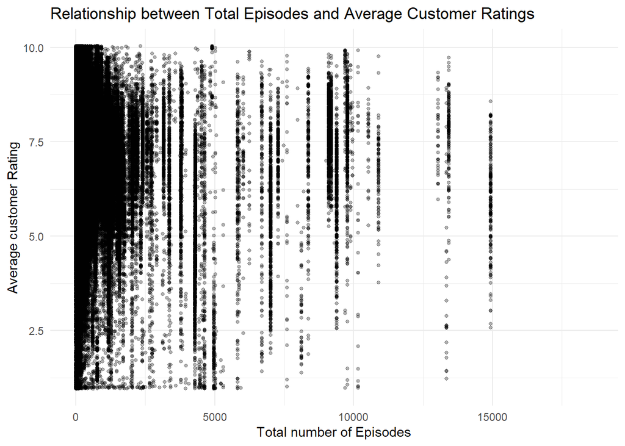

#### Plotting TV Series Length (total years run) vs Average Ratings.

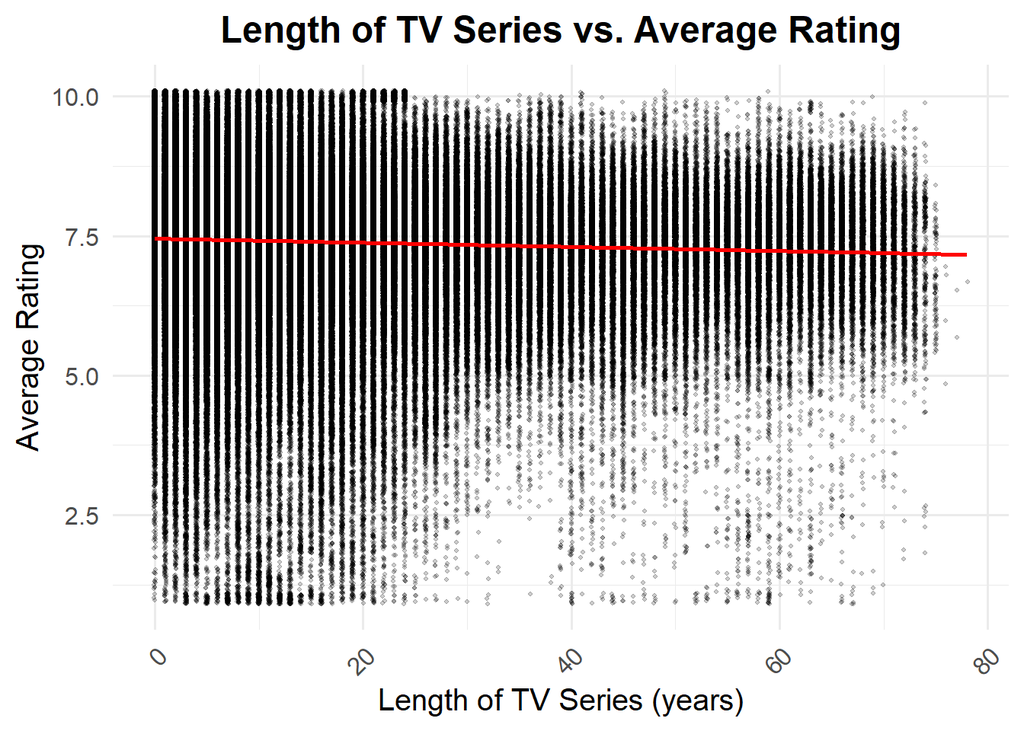

## Preparation

### Motivation for dropping NA’s

#### Motivation for title_basics:

After examining the title_basics dataset, we noticed a significant number of missing values (NAs) in the columns “StartYear,” “EndYear,” “runtimeMinutes,” and “genre.” Since our project requires calculating the series length (series_length = EndYear - StartYear), it is crucial to remove rows with missing values in the “StartYear” and “EndYear” columns. Retaining rows with NAs in these columns would result in inaccurate calculations.

Regarding the missing values in “EndYear,” there is no feasible way to recover this data in our current dataset. Because the “StartYear” and “EndYear” are specific to each TV series, it does not make sense to impute the missing values with estimates or averages, as this would compromise the accuracy of our analysis. Therefore, we will drop all rows where either “StartYear” or “EndYear” is missing to ensure the integrity of our data.

Motivation for title_episode:

In this dataset, we observe missing values (NAs) in the columns “seasonNumber” and “episodeNumber.” Since this information is specific to each TV series, we cannot impute these missing values using data from other TV shows, as doing so would introduce inaccuracies. Additionally, the missing values in these columns are missing at random. Therefore, it is important to drop rows with missing values in these columns.

Motivation for title_ratings:

This dataset does not contain NA’s.

### Now let’s remove NAs from title_basics dataset and show the new summary statistics

```
##     tconst           titleType         primaryTitle       originalTitle
##  Length:58234       Length:58234       Length:58234       Length:58234
##  Class :character   Class :character   Class :character   Class :character
##  Mode  :character   Mode  :character   Mode  :character   Mode  :character
##
##
##
##     isAdult           startYear       endYear     runtimeMinutes
##  Min.   :0.000000   Min.   :1929   Min.   :1932   Min.   :    1.00
##  1st Qu.:0.000000   1st Qu.:1991   1st Qu.:1994   1st Qu.:   25.00
##  Median :0.000000   Median :2008   Median :2010   Median :   34.00
##  Mean   :0.002782   Mean   :2002   Mean   :2004   Mean   :   52.53
##  3rd Qu.:0.000000   3rd Qu.:2017   3rd Qu.:2018   3rd Qu.:   60.00
##  Max.   :1.000000   Max.   :2025   Max.   :2029   Max.   :37440.00
##     genres
##  Length:58234
##  Class :character
##  Mode  :character
##
##
##
```

### Remove NAs from title_episode dataset and show the new summary statistics

```
##     tconst          parentTconst        seasonNumber      episodeNumber
##  Length:6795933     Length:6795933     Min.   :   1.000   Min.   :    0.0
##  Class :character   Class :character   1st Qu.:   1.000   1st Qu.:    7.0
##  Mode  :character   Mode  :character   Median :   1.000   Median :   28.0
##                                        Mean   :   3.799   Mean   :  423.6
##                                        3rd Qu.:   3.000   3rd Qu.:  158.0
##                                        Max.   :2024.000   Max.   :91334.0
```

### Merge the three datsets together

### Create new variable: series_length

A new variable is created that shows how many years a series has run, called series_length. This variable will be the independent variable in our analysis, and is created by deducting the first year that the series ran from the last year.